# Benchmarking

# Intro

Using this Rmd to prepare the benchmarking scripts that I will use in genome.dk

```r
library(bench)
```

# Benchmarking: quickHaplo and RunMacs

Library

```r
library(AlphaSimR)
library(tidyverse)
```

Studying the set of vars to benchmark

for : quickHaplo(nInd = nFounder, nChr = nChr, segSites = segSites)

for : runMacs2(nInd = nFounder, nChr = nChr, segSites = segSites, Ne = 10000)

Comparable: * nInd * nChr * segSites

We should set the Ne of runMacs2 to a reasonable value. 10000 is a common default.genLen has been set to default.

## Parameters

TO MODIFY WITH BIGGER SIZES IN ACTUAL BENCHMARKING

```r
# nInd (Number of Individuals/Founders)

nInd_range <- c(1, 2, 3)

# nChr (Number of Chromosomes)

nChr_range <- c(1, 5, 10)

# segSites (Number of Segregating Sites)

segSites_range <- c(100, 500, 1000)


# Create Parameter Grid


param_grid <- expand.grid(
  nInd = nInd_range,
  nChr = nChr_range,
  segSites = segSites_range,
  stringsAsFactors = FALSE
)
```

Showing how a param_grid look like:

```r
param_grid
```

```
##    nInd nChr segSites
## 1     1    1      100
## 2     2    1      100
## 3     3    1      100
## 4     1    5      100
## 5     2    5      100
## 6     3    5      100
## 7     1   10      100
## 8     2   10      100
## 9     3   10      100
## 10    1    1      500
## 11    2    1      500
## 12    3    1      500
## 13    1    5      500
## 14    2    5      500
## 15    3    5      500
## 16    1   10      500
## 17    2   10      500
## 18    3   10      500
## 19    1    1     1000
## 20    2    1     1000
## 21    3    1     1000
## 22    1    5     1000
## 23    2    5     1000
## 24    3    5     1000
## 25    1   10     1000
## 26    2   10     1000
## 27    3   10     1000
```

## Creat benchmarking function

```r
run_benchmark <- function(nInd, nChr, segSites, Ne = 10000) {

  # Benchmark both methods
  bm <- bench::mark(
     quickHaplo = {
      quickHaplo(
        nInd = nInd,
        nChr = nChr,
        segSites = segSites
      )
    },
    runMacs2 = {
      runMacs2(
        nInd = nInd,
        nChr = nChr,
        segSites = segSites,
        Ne = Ne
      )
    },
    iterations = 10,  # Adjust based on computation time
    check = FALSE,     # Don't check if results are identical
    memory = TRUE      # Track memory usage
  )

  # Add parameter info
  bm$expression <- as.character(bm$expression)
  bm$nInd <- nInd
  bm$nChr <- nChr
  bm$segSites <- segSites
  bm$Ne <- Ne

  return(bm)
}
```

Example of output

```r
run_benchmark(10, 10, 300)
```

```
## # A tibble: 2 × 10
##   expression      min   median `itr/sec` mem_alloc `gc/sec`  nInd  nChr segSites
##   <chr>      <bch:tm> <bch:tm>     <dbl> <bch:byt>    <dbl> <dbl> <dbl>    <dbl>
## 1 quickHaplo   2.99ms   3.66ms    266.       319KB        0    10    10      300
## 2 runMacs2   592.24ms 620.54ms      1.59     256KB        0    10    10      300
## # ℹ 1 more variable: Ne <dbl>
```

## Run benchmarks across parameter grid

```r
# Initialize results list
benchmark_results <- list()

# Progress tracking
total_runs <- nrow(param_grid)
cat("Starting benchmark with", total_runs, "parameter combinations\n")
```

```
## Starting benchmark with 27 parameter combinations
```

```r
# Run benchmarks for each parameter combination
for (i in 1:nrow(param_grid)) {
  cat(sprintf("Progress: %d/%d (%.1f%%) - nInd=%d, nChr=%d, segSites=%d\n",
              i, total_runs, (i/total_runs)*100,
              param_grid$nInd[i], param_grid$nChr[i], param_grid$segSites[i]))

  tryCatch({
    benchmark_results[[i]] <- run_benchmark(
      nInd = param_grid$nInd[i],
      nChr = param_grid$nChr[i],
      segSites = param_grid$segSites[i],
      Ne = 10000
    )
  },
  # If an error occurs, print a message and store NULL for this iteration
  error = function(e) {
    cat("Error in iteration", i, ":", conditionMessage(e), "\n")
    benchmark_results[[i]] <- NULL
  })
}
```

```
## Progress: 1/27 (3.7%) - nInd=1, nChr=1, segSites=100
## Progress: 2/27 (7.4%) - nInd=2, nChr=1, segSites=100
## Progress: 3/27 (11.1%) - nInd=3, nChr=1, segSites=100
## Progress: 4/27 (14.8%) - nInd=1, nChr=5, segSites=100
## Progress: 5/27 (18.5%) - nInd=2, nChr=5, segSites=100
## Progress: 6/27 (22.2%) - nInd=3, nChr=5, segSites=100
## Progress: 7/27 (25.9%) - nInd=1, nChr=10, segSites=100
## Progress: 8/27 (29.6%) - nInd=2, nChr=10, segSites=100
## Progress: 9/27 (33.3%) - nInd=3, nChr=10, segSites=100
## Progress: 10/27 (37.0%) - nInd=1, nChr=1, segSites=500
## Progress: 11/27 (40.7%) - nInd=2, nChr=1, segSites=500
## Progress: 12/27 (44.4%) - nInd=3, nChr=1, segSites=500
## Progress: 13/27 (48.1%) - nInd=1, nChr=5, segSites=500
## Progress: 14/27 (51.9%) - nInd=2, nChr=5, segSites=500
## Progress: 15/27 (55.6%) - nInd=3, nChr=5, segSites=500
## Progress: 16/27 (59.3%) - nInd=1, nChr=10, segSites=500
## Progress: 17/27 (63.0%) - nInd=2, nChr=10, segSites=500
## Progress: 18/27 (66.7%) - nInd=3, nChr=10, segSites=500
## Progress: 19/27 (70.4%) - nInd=1, nChr=1, segSites=1000
## Progress: 20/27 (74.1%) - nInd=2, nChr=1, segSites=1000
## Progress: 21/27 (77.8%) - nInd=3, nChr=1, segSites=1000
## Progress: 22/27 (81.5%) - nInd=1, nChr=5, segSites=1000
## Progress: 23/27 (85.2%) - nInd=2, nChr=5, segSites=1000
## Progress: 24/27 (88.9%) - nInd=3, nChr=5, segSites=1000
## Progress: 25/27 (92.6%) - nInd=1, nChr=10, segSites=1000
## Progress: 26/27 (96.3%) - nInd=2, nChr=10, segSites=1000
## Progress: 27/27 (100.0%) - nInd=3, nChr=10, segSites=1000
```

## Analysis and Visualizations

```r
# Combine all benchmark results into single dataframe
results_df <- bind_rows(benchmark_results)

# Convert time to numeric (seconds)
results_df <- results_df %>%
  mutate(
    time_sec = as.numeric(median),
    mem_alloc_mb = as.numeric(mem_alloc) / 1024^2
  )
```

SUMMARY

```r
## Summary Statistics
summary_stats <- results_df %>%
  group_by(expression) %>%
  summarise(
    mean_time__sec = mean(time_sec),
    median_time_sec = median(time_sec),
    min_time_sec = min(time_sec),
    max_time_sec = max(time_sec),
    mean_mem_MB = mean(mem_alloc_mb),
    .groups = 'drop'
  )

summary_stats
```

```
## # A tibble: 2 × 6
##   expression mean_time__sec median_time_sec min_time_sec max_time_sec
##   <chr>               <dbl>           <dbl>        <dbl>        <dbl>
## 1 quickHaplo        0.00301         0.00211     0.000891      0.00852
## 2 runMacs2          0.133           0.113       0.0399        0.304
## # ℹ 1 more variable: mean_mem_MB <dbl>
```

COMPARISON BY PARAMETERS

```r
## Compare by parameter
comparison_by_param <- results_df %>%
  select(expression, nInd, nChr, segSites, time_sec, mem_alloc_mb) %>%
  tidyr::pivot_wider(
    names_from = expression,
    values_from = c(time_sec, mem_alloc_mb)
  ) %>%
  mutate(
    speedup_Macs2 = time_sec_runMacs2 / time_sec_quickHaplo,
    mem_ratio_Macs2 = mem_alloc_mb_runMacs2 / mem_alloc_mb_quickHaplo
  )

comparison_by_param
```

```
## # A tibble: 27 × 9
##     nInd  nChr segSites time_sec_quickHaplo time_sec_runMacs2
##    <dbl> <dbl>    <dbl>               <dbl>             <dbl>
##  1     1     1      100            0.000891            0.0416
##  2     2     1      100            0.000900            0.0815
##  3     3     1      100            0.000902            0.106
##  4     1     5      100            0.00161             0.0585
##  5     2     5      100            0.00155             0.113
##  6     3     5      100            0.00138             0.139
##  7     1    10      100            0.00293             0.114
##  8     2    10      100            0.00321             0.216
##  9     3    10      100            0.00193             0.288
## 10     1     1      500            0.00131             0.0399
## # ℹ 17 more rows
## # ℹ 4 more variables: mem_alloc_mb_quickHaplo <dbl>,
## #   mem_alloc_mb_runMacs2 <dbl>, speedup_Macs2 <dbl>, mem_ratio_Macs2 <dbl>
```

# WEEK9: New version with different threads and different Ne

## This is my version on my laptop. small example, no cluster

```r
df <- readRDS("benchmarking_haplo/script_threads.rds")
df <- df %>%
  mutate(
    nThreads = as.character(nThreads),
    nChr = as.character(nChr),
    nInd = as.character(nInd),
    Ne = as.character(Ne)
  )

df$nChr <- factor(df$nChr, levels = c("1", "5", "8", "10"))
df$nThreads <- factor(df$nThreads, levels = c("1", "5", "8", "10"))
df
```

```
## # A tibble: 16 × 11
##    nInd  nChr  segSites nThreads Ne    time_sec_quickHaplo time_sec_runMacs2
##    <chr> <fct>    <dbl> <fct>    <chr>               <dbl>             <dbl>
##  1 100   1          100 1        100              0.000888             0.405
##  2 100   5          100 1        100              0.00178              2.00
##  3 100   8          100 1        100              0.00205              3.31
##  4 100   10         100 1        100              0.00278              4.26
##  5 100   1          100 5        100              0.000756             0.387
##  6 100   5          100 5        100              0.00172              0.545
##  7 100   8          100 5        100              0.00216              1.02
##  8 100   10         100 5        100              0.00341              1.16
##  9 100   1          100 8        100              0.00110              0.472
## 10 100   5          100 8        100              0.00216              0.560
## 11 100   8          100 8        100              0.00258              0.678
## 12 100   10         100 8        100              0.00246              1.05
## 13 100   1          100 10       100              0.000814             0.389
## 14 100   5          100 10       100              0.00174              0.506
## 15 100   8          100 10       100              0.00233              0.645
## 16 100   10         100 10       100              0.00288              0.937
## # ℹ 4 more variables: mem_alloc_mb_quickHaplo <dbl>,
## #   mem_alloc_mb_runMacs2 <dbl>, speedup_Macs2 <dbl>, mem_ratio_Macs2 <dbl>
```

Plotting to see what happend when more core than possible.

Changing the parameters to strings.

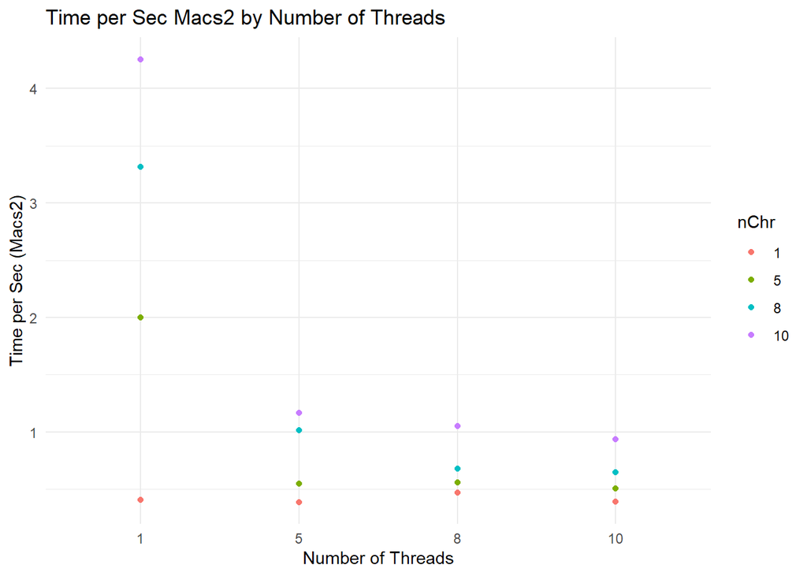

```r
library(ggplot2)
ggplot(df, aes(x = nThreads, y = time_sec_runMacs2)) +
  geom_point(aes(colour = nChr)) +
  labs(title = "Time per Sec Macs2 by Number of Threads",
       x = "Number of Threads",
       y = "Time per Sec (Macs2)") +
  theme_minimal()+
  geom_smooth(method = "loess", se = FALSE, color = "blue")
```

# ACTUAL RESULTS THREAD ANALYSIS FROM CLUSTER

**RESULTS BASED ON TIME PER SECOND**

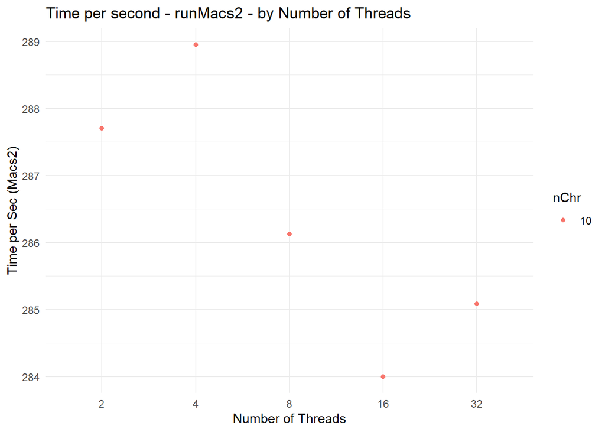

```r
library(tidyverse)
df <- readRDS("benchmarking_haplo/combined_results_old.rds")
df <- df %>%
  mutate(
    nThreads = as.character(nThreads),
    nChr = as.character(nChr),
    nInd = as.character(nInd),
    Ne = as.character(Ne)
  )
df$nThreads <- factor(df$nThreads, levels = c("2", "4", "8", "16", "32"))
ggplot(df, aes(x = nThreads, y = time_sec_runMacs2)) +
  geom_point(aes(colour = nChr)) +
  labs(title = "Time per second - runMacs2 - by Number of Threads",
       x = "Number of Threads",
       y = "Time per Sec (Macs2)") +
  theme_minimal()+
  geom_smooth(method = "loess", se = FALSE, color = "blue")
```

**SPEEDUP ANALYSIS COMPARED TO QUICKHAPLO**

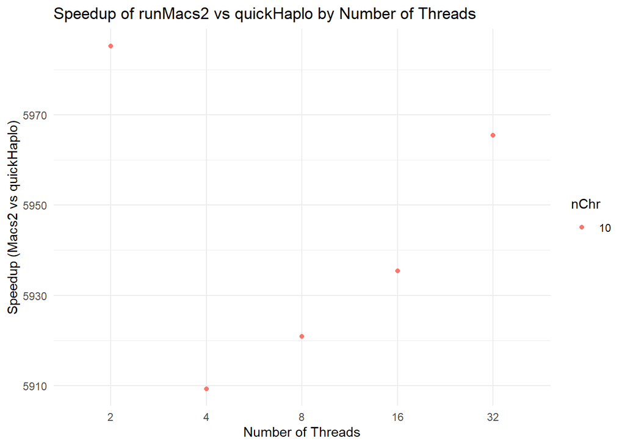

```r
ggplot(df, aes(x = nThreads, y = speedup_Macs2)) +
  geom_point(aes(colour = nChr)) +
  labs(title = "Speedup of runMacs2 vs quickHaplo by Number of Threads",
       x = "Number of Threads",
       y = "Speedup (Macs2 vs quickHaplo)") +
  theme_minimal()+
  geom_smooth(method = "loess", se = FALSE, color = "blue")
```

**PRINT DATA**

```r
df
```

```
## # A tibble: 5 × 11
##   nInd  nChr  segSites nThreads Ne    time_sec_quickHaplo time_sec_runMacs2
##   <chr> <chr>    <dbl> <fct>    <chr>               <dbl>             <dbl>
## 1 1000  10        1000 2        10000              0.0481              288.
## 2 1000  10        1000 4        10000              0.0489              289.
## 3 1000  10        1000 8        10000              0.0483              286.
## 4 1000  10        1000 16       10000              0.0478              284.
## 5 1000  10        1000 32       10000              0.0478              285.
## # ℹ 4 more variables: mem_alloc_mb_quickHaplo <dbl>,
## #   mem_alloc_mb_runMacs2 <dbl>, speedup_Macs2 <dbl>, mem_ratio_Macs2 <dbl>
```

It looks like increasing the nomber of threads doesn’t improve the speed of the runMacs2 after 16 threads,it even gets worse. This could be due to overhead from managing too many threads or contention for resources. The optimal number of threads seems to be around 16 for this particular setup.

My theory: number of threads ideally should be closer to the number of chromosomes

**RESULTS NEW THEORY**

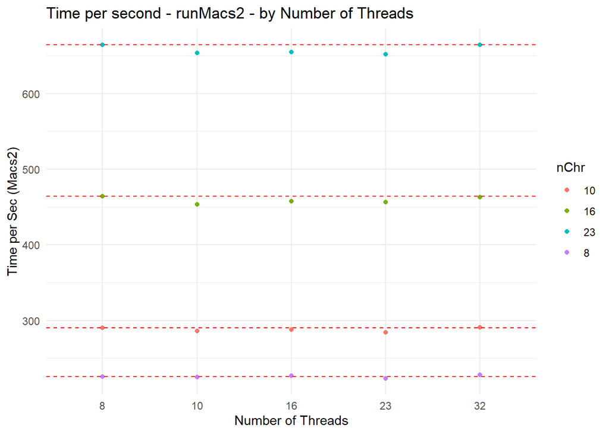

```r
library(tidyverse)
df <- readRDS("benchmarking_haplo/combined_results.rds") %>%
  mutate(
    nThreads = as.character(nThreads),
    nChr = as.character(nChr),
    nInd = as.character(nInd),
    Ne = as.character(Ne)
  )

df$nThreads <- factor(df$nThreads, levels = c("8","10", "16","23", "32"))

ggplot(df, aes(x = nThreads, y = time_sec_runMacs2)) +
  geom_point(aes(colour = nChr)) +
  labs(title = "Time per second - runMacs2 - by Number of Threads",
       x = "Number of Threads",
       y = "Time per Sec (Macs2)") +
  theme_minimal() +
  # Adding straight horizontal line at the height of each point at 8 threads
  geom_hline(data = df %>% filter(nThreads == "8"), aes(yintercept = time_sec_runMacs2), linetype = "dashed", color = "red")
```

Dfferences are so small that it’s hard to see any difference. Filtering by chromosomes.

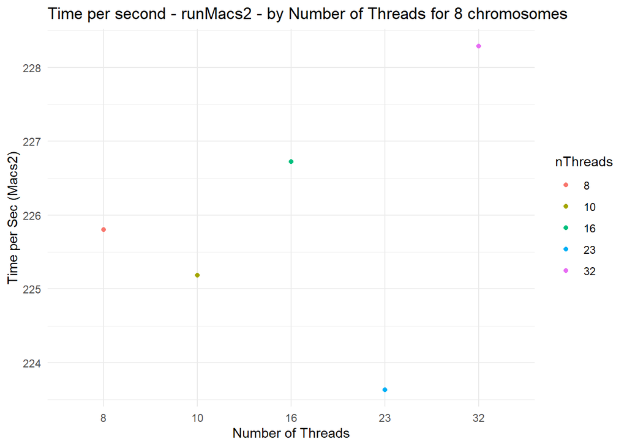

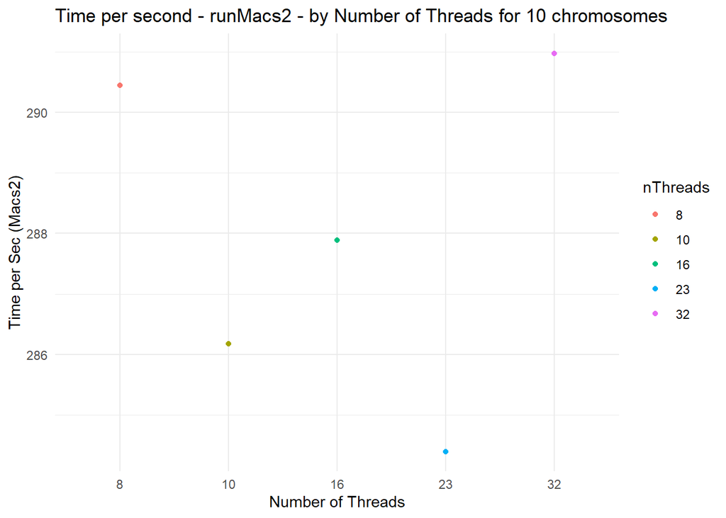

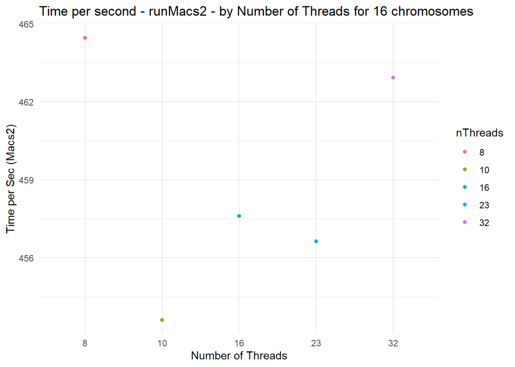

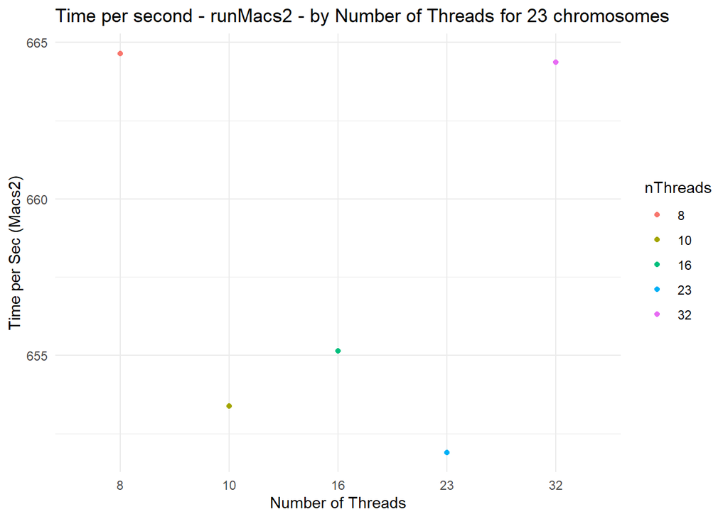

```r
list_chr <- unique(df$nChr)
for (chr in list_chr) {
  df_chr <- df %>% filter(nChr == chr)
  p <- ggplot(df_chr, aes(x = nThreads, y = time_sec_runMacs2, colour = nThreads))+
    geom_point() +
    labs(title = paste("Time per second - runMacs2 - by Number of Threads for", chr, "chromosomes"),
         x = "Number of Threads",
         y = "Time per Sec (Macs2)") +
    theme_minimal()
  print(p)
}
```

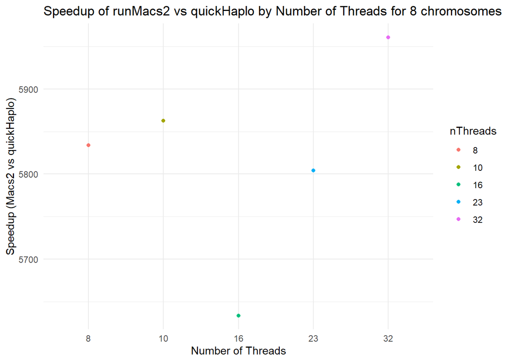

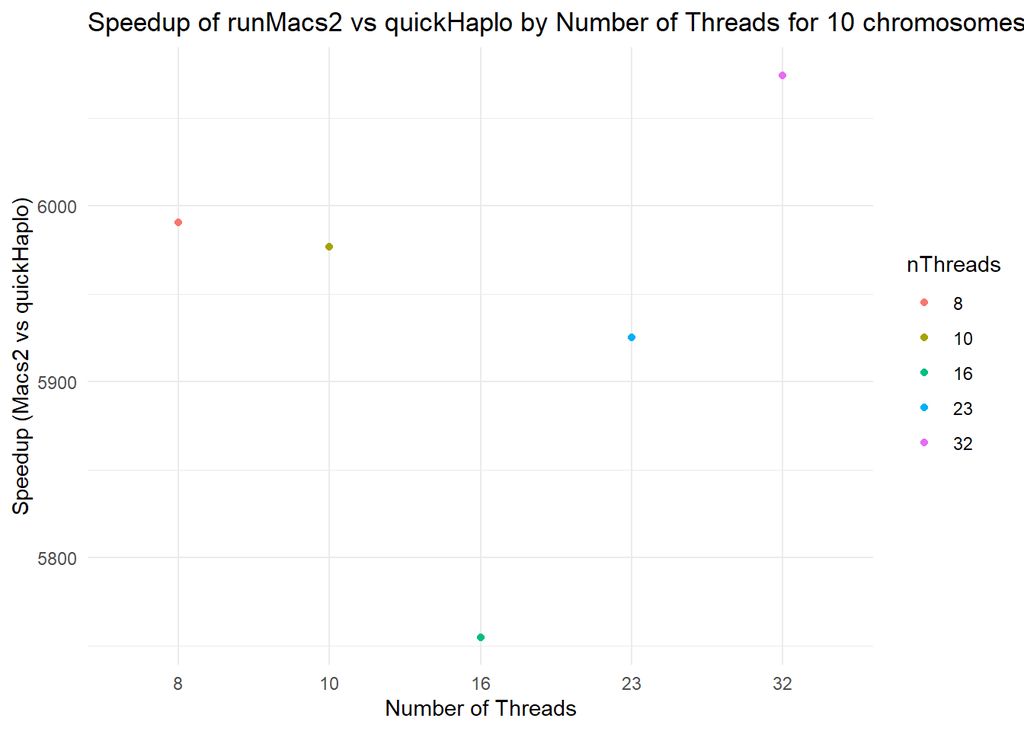

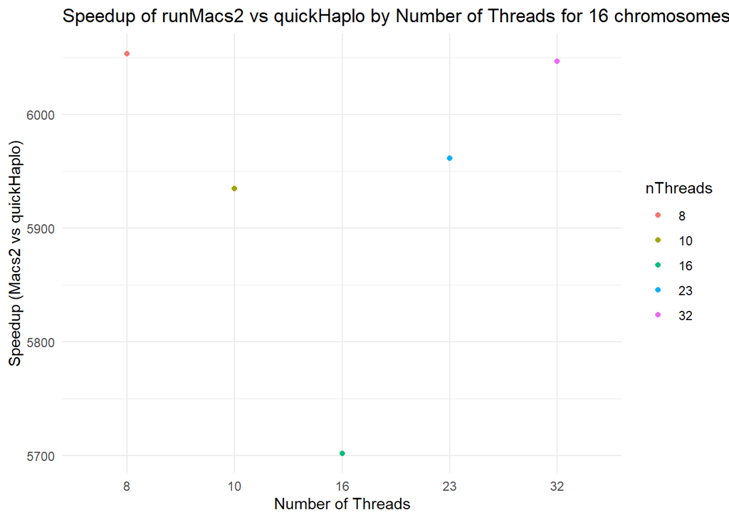

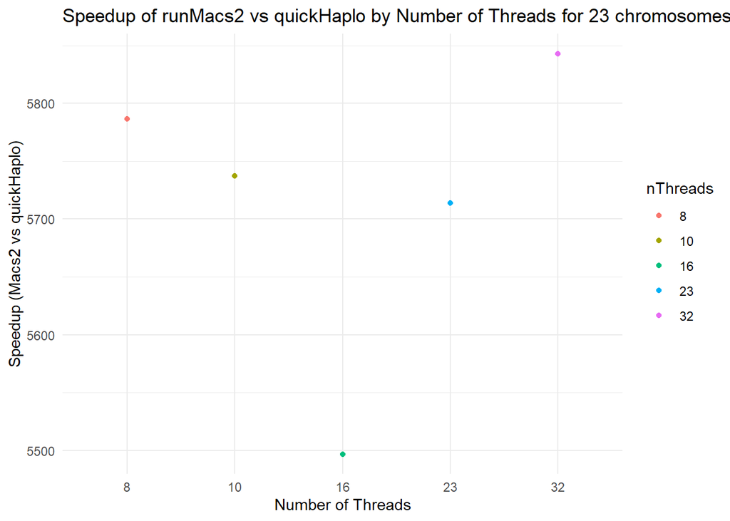

```r
# showing the speedup for each chromosome separately
for (chr in list_chr) {
  df_chr <- df %>% filter(nChr == chr)
  p <- ggplot(df_chr, aes(x = nThreads, y = speedup_Macs2, colour = nThreads))+
    geom_point() +
    labs(title = paste("Speedup of runMacs2 vs quickHaplo by Number of Threads for", chr, "chromosomes"),
         x = "Number of Threads",
         y = "Speedup (Macs2 vs quickHaplo)") +
    theme_minimal()
  print(p)
}
```

**SHOWING SPEEDUP WITH THREADS AND NCHR**

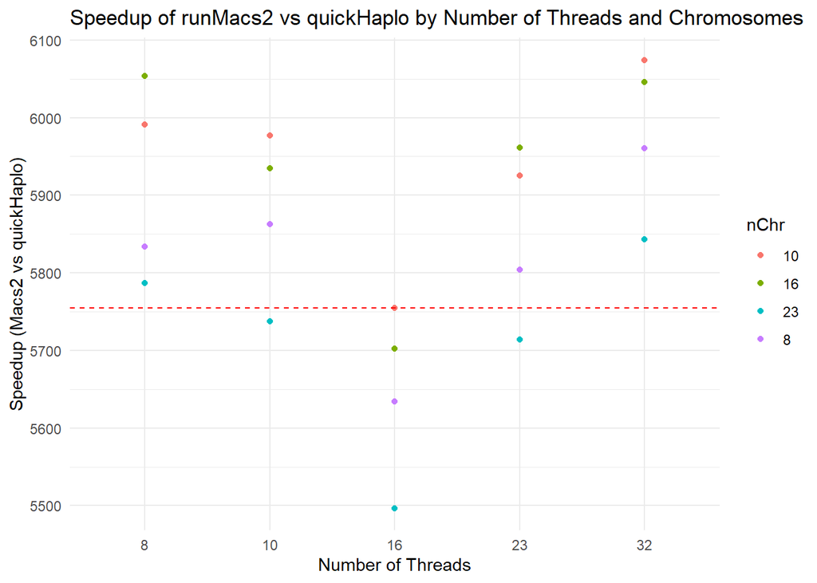

```r
p <- ggplot(df, aes(x = nThreads, y = speedup_Macs2, colour = nChr))+
  geom_point() +
  labs(title = "Speedup of runMacs2 vs quickHaplo by Number of Threads and Chromosomes",
       x = "Number of Threads",
       y = "Speedup (Macs2 vs quickHaplo)") +
  theme_minimal()+
  # add horizontal line at 16 threads
  geom_hline(data = df %>% filter(nThreads == "16" & nChr=="10"), aes(yintercept = speedup_Macs2), linetype = "dashed", color = "red")
p
```

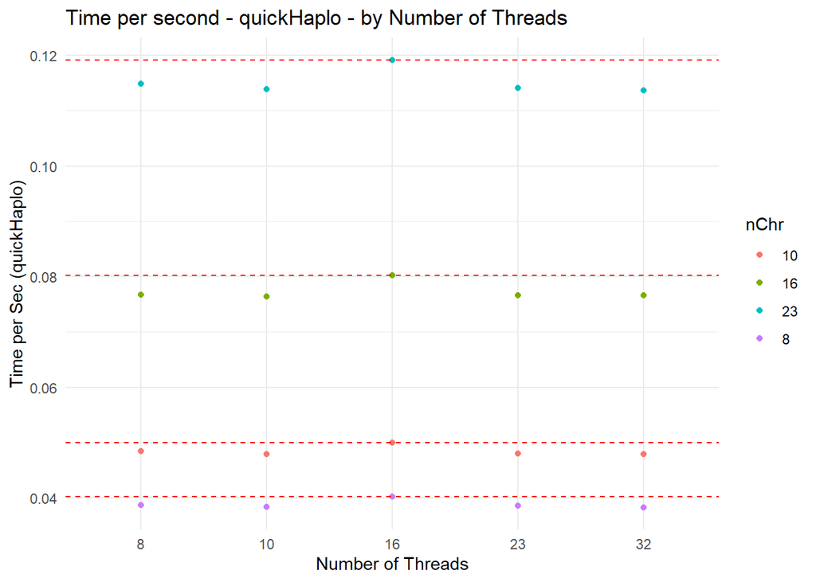

```r
# plot time per sec of quickhaplo
p <- ggplot(df, aes(x = nThreads, y = time_sec_quickHaplo, colour = nChr))+
  geom_point() +
  labs(title = "Time per second - quickHaplo - by Number of Threads",
       x = "Number of Threads",
       y = "Time per Sec (quickHaplo)") +
  theme_minimal()+
  # add horizontal line at 16 threads
  geom_hline(data = df %>% filter(nThreads == "16"), aes(yintercept = time_sec_quickHaplo), linetype = "dashed", color = "red")
print(p)
```

**CHECKING INCREASE IN TIME FOR RUNMACS2 AND QUICKHAPLO JUST BASED ON THE NUMBER OF CHROMOSOMES**

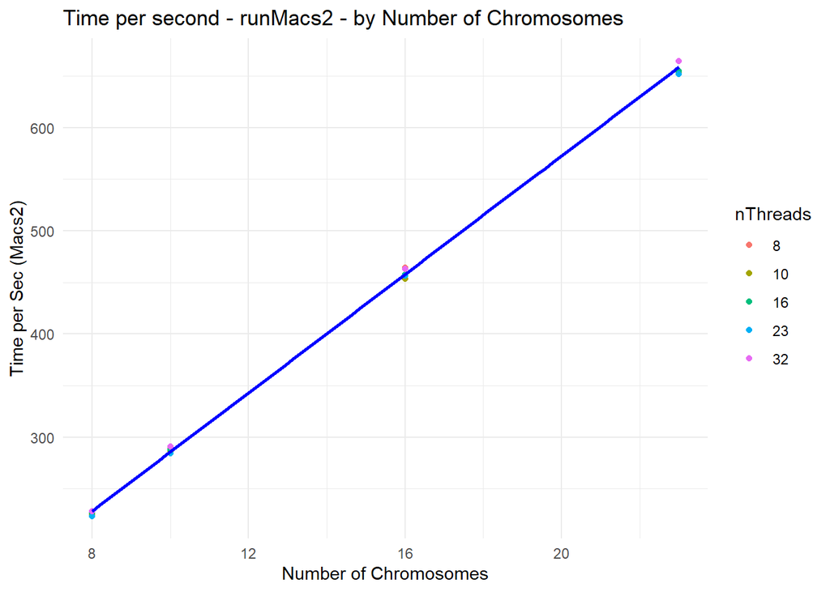

```r
library(tidyverse)
df <- readRDS("benchmarking_haplo/combined_results.rds") %>%
  mutate(
    nThreads = as.character(nThreads),
    nInd = as.character(nInd),
    Ne = as.character(Ne)
  )

df$nThreads <- factor(df$nThreads, levels = c("8","10", "16","23", "32"))

p <- ggplot(df, aes(x = nChr, y = time_sec_runMacs2, colour = nThreads)) +
  geom_point() +
  labs(title = "Time per second - runMacs2 - by Number of Chromosomes",
       x = "Number of Chromosomes",
       y = "Time per Sec (Macs2)") +
  theme_minimal() +
  geom_smooth(method = "lm", se = FALSE, color = "blue") +
  # change scale x axis to fit the number of chromosomes
  scale_x_continuous(
    breaks = seq(8, 24, by = 4),
  )

p
```

# Cluster results for Ne

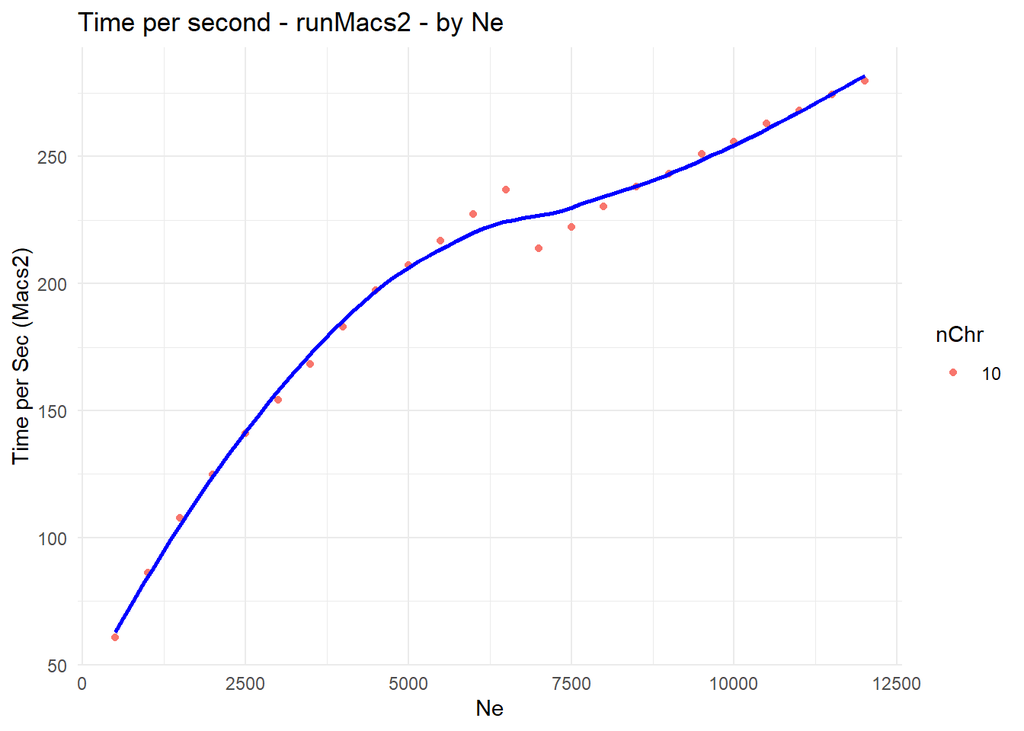

```r
df <- readRDS("benchmarking_haplo/bench_Ne.rds")
df <- df %>%
  mutate(
    nThreads = as.character(nThreads),
    nChr = as.character(nChr),
    nInd = as.character(nInd)
  )

p <- ggplot(df, aes(x = Ne, y = time_sec_runMacs2)) +
  geom_point(aes(colour = nChr)) +
  labs(title = "Time per second - runMacs2 - by Ne",
       x = "Ne",
       y = "Time per Sec (Macs2)") +
  # log smoothing method
  geom_smooth(method = "loess", se = FALSE, color = "blue") +

  theme_minimal()
p
```

```r
# coefficient
model <- lm(time_sec_runMacs2 ~ Ne, data = df)
model$coefficients
```

```
## (Intercept)          Ne
## 98.89851586  0.01652145
```

**LOG SCAL FOR Ne**

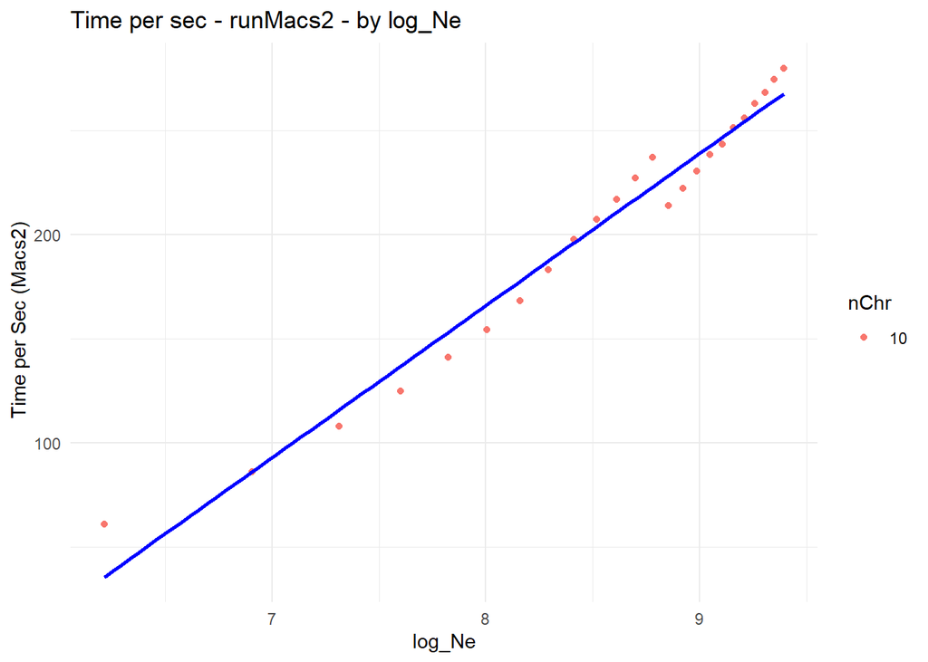

```r
df_log <- df %>%
  mutate(log_Ne = log(Ne))
p <- ggplot(df_log, aes(x = log_Ne, y = time_sec_runMacs2)) +
  geom_point(aes(colour = nChr)) +
  labs(title = "Time per sec - runMacs2 - by log_Ne",
       x = "log_Ne", y = " Time per Sec (Macs2)") +
  geom_smooth(method = "lm", se = FALSE, color = "blue") +
  theme_minimal()
p
```

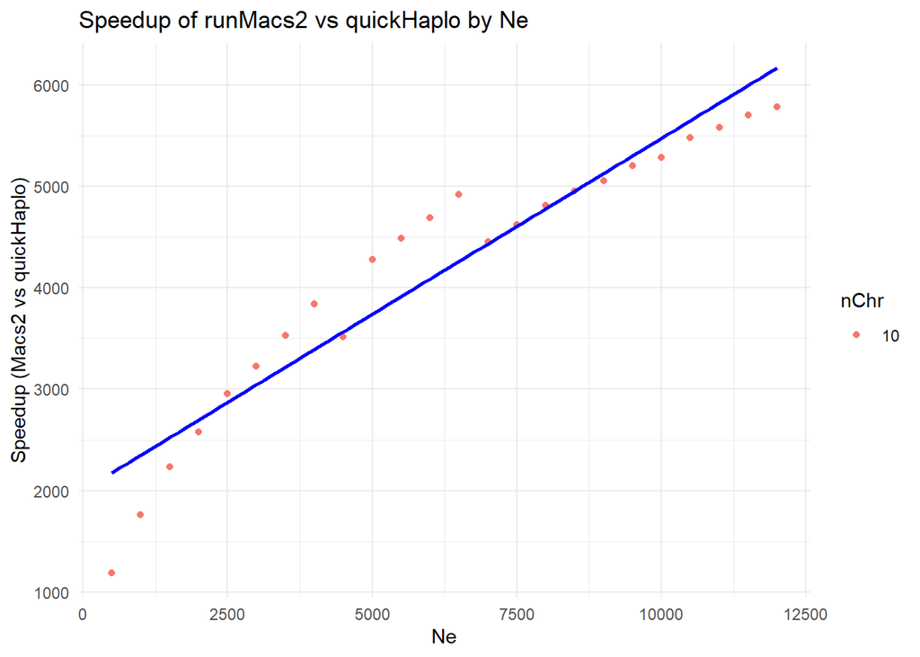

```r
# speedup comparison for Ne

p <- ggplot(df, aes(x = Ne, y = speedup_Macs2))+
  geom_point(aes(colour = nChr)) +
  labs(title = "Speedup of runMacs2 vs quickHaplo by Ne",
       x = "Ne",
       y = "Speedup (Macs2 vs quickHaplo)") +
  theme_minimal()+
  # print on the slope of the speedup through geom_smooth
  geom_smooth(method = "lm", se = FALSE, color = "blue")


p
```

```r
# get slope

model <- lm(speedup_Macs2 ~ Ne, data = df)
model$coefficients
```

```
##  (Intercept)           Ne
## 2001.0702219    0.3472505
```

# WEEK10

# TESTING NE EXTENDED

```r
df <- readRDS("benchmarking_haplo/combined_results_Ne_extended.rds")
```

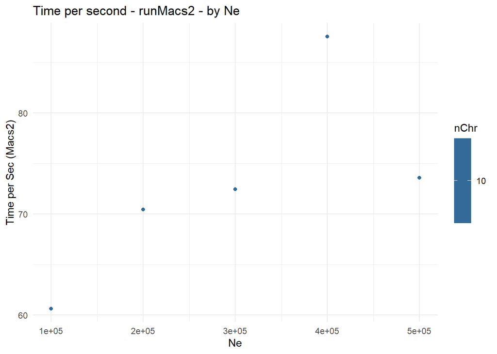

```r
library(tidyverse)
ggplot(df, aes(x = Ne, y = time_sec_runMacs2)) +
  geom_point(aes(colour = nChr)) +
  labs(title = "Time per second - runMacs2 - by Ne",
       x = "Ne",
       y = "Time per Sec (Macs2)") +
  theme_minimal()
```

```r
  # log smoothing method
```

Now let’s test if difference when different chr

```r
df <- readRDS("benchmarking_haplo/combined_results_Ne_extended.rds") %>%
  mutate(
    nThreads = as.character(nThreads),
    nInd = as.character(nInd)
  )
```

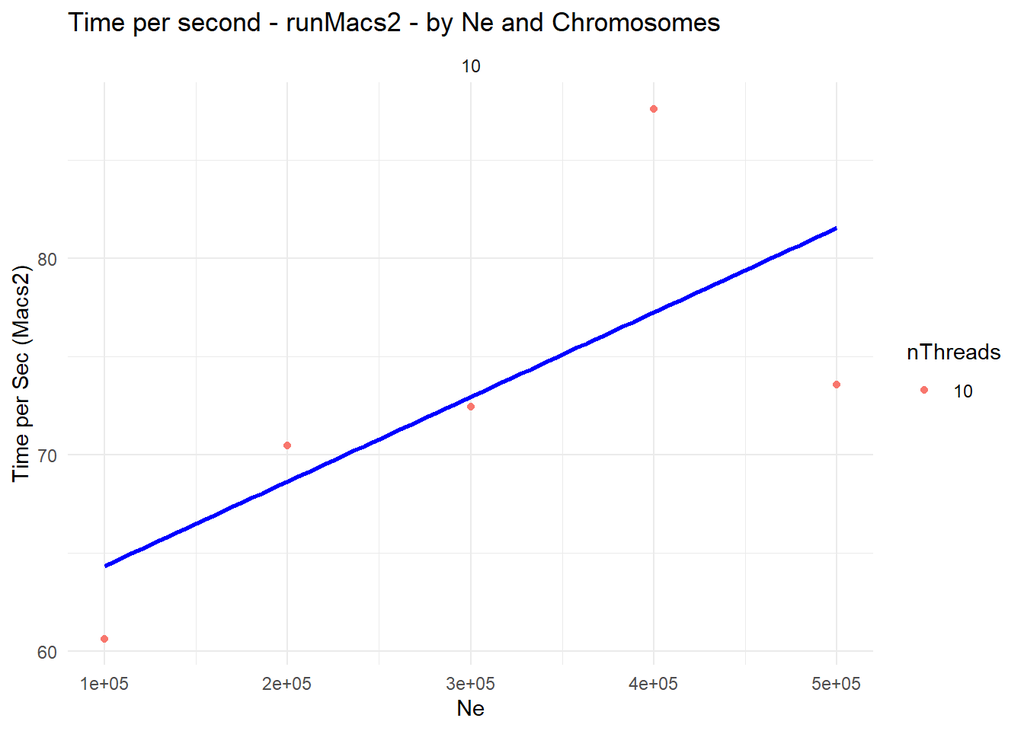

```r
ggplot(df, aes(x = Ne, y = time_sec_runMacs2)) +
  geom_point(aes(colour = nThreads)) +
  labs(title = "Time per second - runMacs2 - by Ne and Chromosomes",
       x = "Ne",
       y = "Time per Sec (Macs2)") +
  theme_minimal() +
  geom_smooth(method = "lm", se = FALSE, color = "blue") +
  facet_wrap(~nChr)
```

It looks like it’s working. Let’s run the big bench.

# Complete analysis NE extended

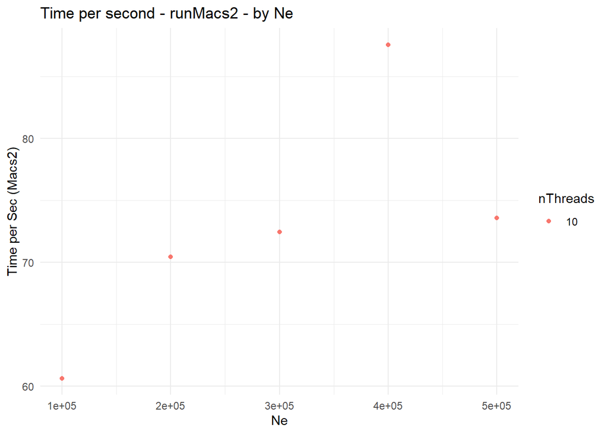

```r
library(tidyverse)
df <- readRDS("benchmarking_haplo/combined_results_Ne_extended.rds") %>%
  mutate(
    nThreads = as.character(nThreads),
    nInd = as.character(nInd)
  )

ggplot(df, aes(x = Ne, y = time_sec_runMacs2)) +
  geom_point(aes(colour = nThreads)) +
  labs(title = "Time per second - runMacs2 - by Ne",
       x = "Ne",
       y = "Time per Sec (Macs2)") +
  theme_minimal()
```

Check what happens when Ne is 400000

Results:

```r
library(tidyverse)
```

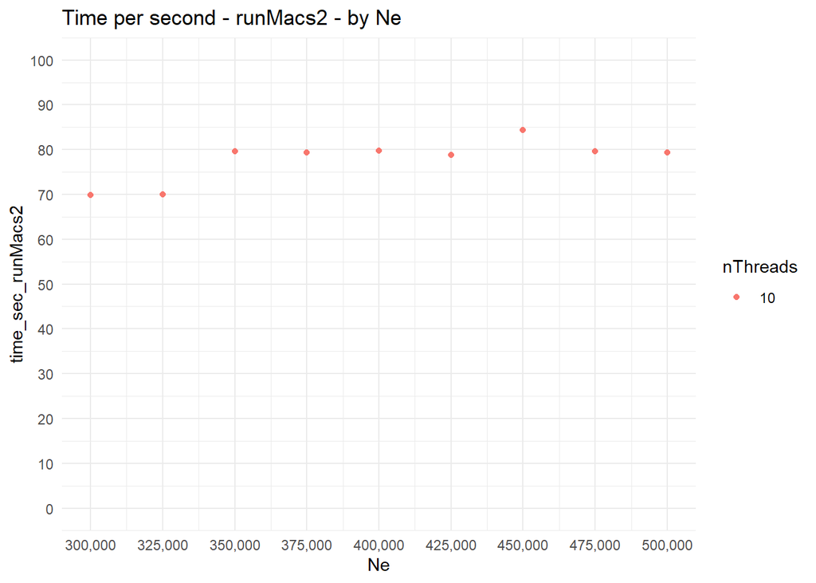

```r
df <- readRDS("benchmarking_haplo/bench_Ne_extended_2.rds") %>%
  mutate(
    nThreads = as.character(nThreads),
    nInd = as.character(nInd)
  )

ggplot(df, aes(x = Ne, y = time_sec_runMacs2)) +
  geom_point(aes(colour = nThreads)) +
  labs(title = "Time per second - runMacs2 - by Ne") +
  theme_minimal() +
  scale_x_continuous(
    breaks = seq(300000, 500000, by= 25000),
    labels = scales::comma
  )+
  scale_y_continuous(limits = c(0, 100),
    breaks = seq(0, 100, by = 10))
```